# Figures

# Comparison of resuts of gene-set enrichment analyses (Supplementary figure 2)

Supplementary figure 2 is meant only to show that the enrichment analyses performed with two alternative gene orderings are equivalent. The two gene orders correspond to: a) the $p$ value of the differential gene expression analysis performed in `2020-01-08` with the `dream()` function; and b) the amount of variance in gene expression explained by the relevant factor (selective regime). The gene-set enrichment analyses (`2020-01-14`) determine how significantly enriched gene ontology terms are among the top genes. The scatterplots below, thus, represent gene ontology terms. I use ranks, instead of $p$ values, because the distribution of ranks makes the relationship easier to visualize. In any case, the purpose of those plots is simply to note that the two alternative gene orderings offer very similar results.

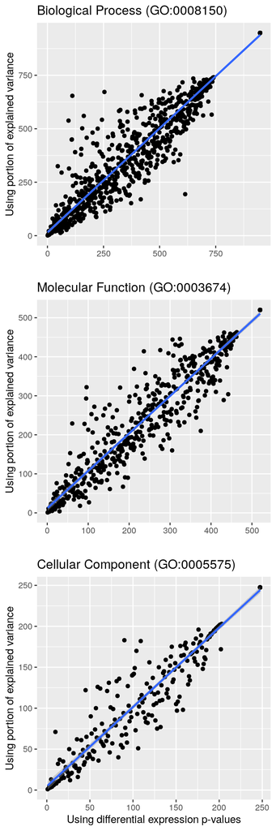

```r
load(GO.results)
allTerms <- usedGO(GOdata.BP)
stopifnot(all.equal(usedGO(GOdata.BP), usedGO(GOdataVar.BP)))
p1 <- ggplot(data = data.frame(DGE     = rank(score(BP.weight01))[allTerms],
                               VarPart = rank(score(BPvar.weight01))[allTerms]),
             mapping = aes(x = DGE, y = VarPart)) + geom_point() +
  geom_smooth(method='lm') + xlab('') +
  ylab('Using portion of explained variance') + ggtitle('Biological Process (GO:0008150)')

allTerms <- usedGO(GOdata.MF)
stopifnot(all.equal(usedGO(GOdata.MF), usedGO(GOdataVar.MF)))
p2 <- ggplot(data = data.frame(DGE     = rank(score(MF.weight01))[allTerms],
                               VarPart = rank(score(MFvar.weight01))[allTerms]),
             mapping = aes( x = DGE, y = VarPart)) + geom_point() +
  geom_smooth(method = 'lm') + xlab('') +
  ylab('Using portion of explained variance') + ggtitle('Molecular Function (GO:0003674)')

allTerms <- usedGO(GOdata.CC)
stopifnot(all.equal(usedGO(GOdata.CC), usedGO(GOdataVar.CC)))
p3 <- ggplot(data = data.frame(DGE     = rank(score(CC.weight01))[allTerms],
                               VarPart = rank(score(CCvar.weight01))[allTerms]),
             mapping = aes( x = DGE, y = VarPart)) + geom_point() +
  geom_smooth(method = 'lm') + xlab('Using differential expression p-values') +
  ylab('Using portion of explained variance') + ggtitle('Cellular Component (GO:0005575)')

p4 <- grid.arrange(p1, p2, p3, ncol=1)
```

```r
p4
```

```r
ggsave('FigureS2.png', plot = p4)
```